# MAT150 - Summer 2023

Phd. Anabela Romina Turlione

Digipen, Bilbao

# The limit of a Function

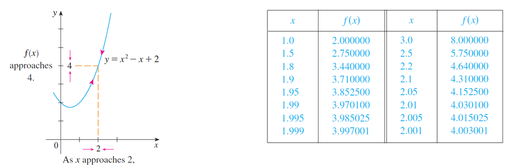

It appears that we can make the values of $f(x)$ as close as we like to $4$ by taking $x$ sufficiently close to 2. We express this by saying “the limit of the function as approaches 2 is equal to 4.”

Notation:

\begin{equation} \lim_{x\to 2} (x^2-x+2) = 4 \end{equation}

**Definition**

\begin{equation} \lim_{x\to a} f(x) = L \end{equation}

Means that we can make the values of $f(x)$ arbitrarily close to $L$ (as close to $L$ as we like) by taking $x$ to be sufficiently close to $a$ (on either side of $a$) but not equal to $a$.

- In finding the limit of $ f(x) $ as $x$ approaches $a$, we never consider $x=a$.
- In fact, $ f(x) $ need not even be defined when $x=a$.
- The only thing that matters is how it is defined near $a$.

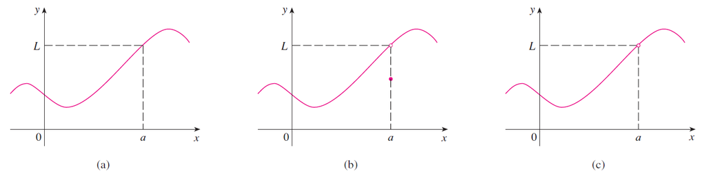

In each case, regardless of what happens at $a$, it is true that $ \lim_{x\to a} f(x) = L$.

**Example:** Guess the value of

\begin{equation} \lim_{x\to 1} \frac{x-1}{x^2-1} \end{equation}

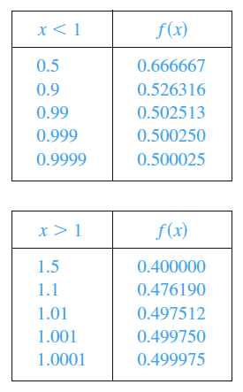

What is the limit of $ f(x)=\left\lbrace \begin{array}{ll} \frac{x-1}{x^2-1}, ~~ if x\ne 1 \\ 2,~~ x = 1 \end{array} \right. $ ?

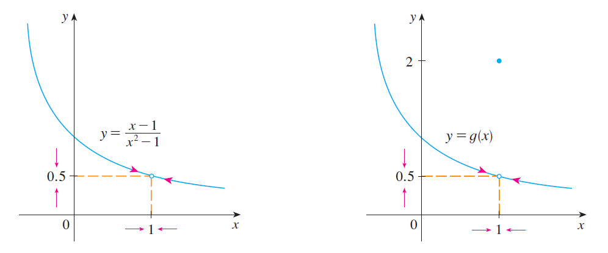

In both cases, $\lim_{x\to 1} f(x)=0.5$

# Definition of Limit

To motivate the precise definition of a limit, let’s consider the function

\begin{equation} f(x)=\left\lbrace \begin{array}{ll} 2x-1, ~~ if x\ne 3 \\ 6,~~ x = 3 \end{array} \right. \end{equation}

Intuitively, $\lim_{x\to 3} f(x) = 5$

- Such phrases as “$x$ is close to $3$” and “$f(x)$ gets closer and closer to $5$” are vague.
- We ask instead, “How close to $3$ does $x$ have to be so that $f(x)$ differs from $5$ by less than $0.l$?”
- So, our problem is to find a number $\delta$ such that:

\begin{equation} |f(x)-5| < 0.1 ~~~ if ~~~ |x-3| < \delta ~~~ but ~x\ne3 \end{equation}

\begin{equation} |f(x)-5| < 0.1 \Rightarrow |2x-1-5| < 0.1 \end{equation}

\begin{equation} \Rightarrow |2x-6| < 0.1 \Rightarrow |2(x-3)| < 0.1 \end{equation}

In a simmilar way:

By the same reasoning:

\begin{equation} |f(x)-5| < \epsilon ~~~ if ~~~ 0< |x-3| < \delta = \frac{\epsilon}{2} \end{equation}

Or...

\begin{equation} if ~~~ 3-\delta < x < 3 + \delta ~~~ (x \ne 3) ~~~~~~ then ~~~~~~ 5-\epsilon < f(x) < 5 + \epsilon \end{equation}

## Precise definition of a limit

Let $f$ be a function defined on some open interval that contains the number $a$, except possibly at $a$ itself. Then we say that the **limit of** $f(x)$ **as** $x$ **approaches** $a$ is $L$, and we write

\begin{equation} \lim_{x\to a} f(x) = L \end{equation}

if for every number $\epsilon > 0$ there is a number $\delta > 0$ such that

\begin{equation} if ~~~ 0< |x-a| < \delta ,~~~ then ~~~ |f(x)-L| < \epsilon \end{equation}

Another way to say the same thing is:

\begin{equation} \lim_{x\to a} f(x) = L \Leftrightarrow \forall ~~~ \epsilon > 0 ~~~ \exists \delta >0 / |x-a|<\delta \Rightarrow |f(x)-L|<\epsilon \end{equation}

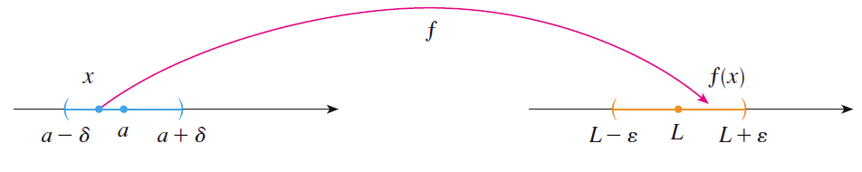

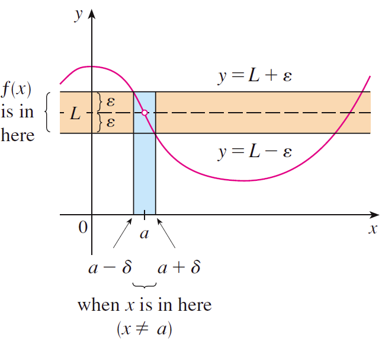

## Left-hand limit

\begin{equation} \lim_{x\to a^-} f(x) = L \Leftrightarrow \forall ~~~ \epsilon > 0 ~~~ \exists ~~ \delta >0 ~/ ~a-\delta <x<a \Rightarrow |f(x)-L|<\epsilon \end{equation}

## Right-hand limit

\begin{equation} \lim_{x\to a^+} f(x) = L \Leftrightarrow \forall ~~~ \epsilon > 0 ~~~ \exists ~~ \delta >0 ~/ ~a<x<a+\delta \Rightarrow |f(x)-L|<\epsilon \end{equation}

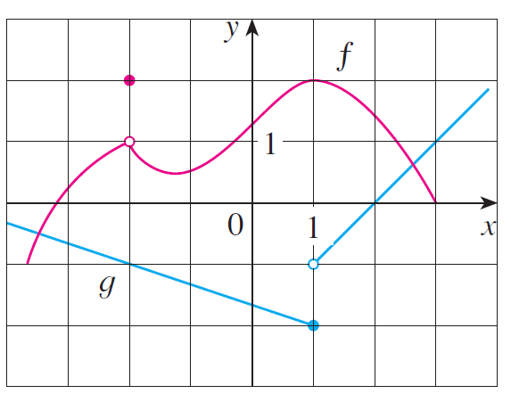

## Theorem: Existence of a limit

\begin{equation} \lim_{x\to a} f(x) = L \Leftrightarrow \lim_{x\to a^-} f(x) = \lim_{x\to a^+} f(x)=L ~~~ \& ~~~ it~ is~ UNIQUE \end{equation}

**Example:**

Calculate

\begin{equation} \lim_{x\to 1} \frac{2x}{x-3}=\frac{2}{1-3}=-1 \end{equation}

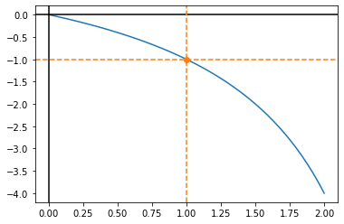

```python
import matplotlib.pyplot as plt
import numpy as np


x=np.linspace(0,2)

plt.plot(x,2*x/(x-3))
plt.plot(1,-1,'o')

plt.axvline(x = 0, color = 'k')
plt.axhline(y = 0, color = 'k')
plt.axhline(y = -1,linestyle ='--', color = 'tab:orange')
plt.axvline(x = 1,linestyle ='--', color = 'tab:orange')
```

## Definition

Let $f$ be defined on both sides of $a$, except possibly at $a$ itself. Then

\begin{equation} \lim_{x\to a} f(x) = +\infty \end{equation}

means that the values of $f(x)$ can be made arbitrarily large positive by taking $x$ sufficiently close to $a$, but not equal to $a$.

That is,

\begin{equation} \lim_{x\to a} f(x) = +\infty \Leftrightarrow \forall ~~~ M > 0 ~~~ \exists ~~ \delta >0 ~\big/ ~0<|x-a|<\delta \Rightarrow f(x)>M \end{equation}

```
(0.0, 2.0)
```

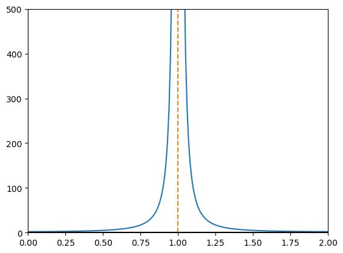

```python
import matplotlib.pyplot as plt
import numpy as np

x = np.linspace (1.01,2,100)
x1 = np.linspace (0,0.99,100)
plt.plot(x, 1/(x-1)**2+1)
plt.plot(x1, 1/(x1-1)**2+1,color='tab:blue')
plt.axvline(x = 1, color = 'tab:orange', linestyle = '--')
plt.axvline(x = 0, color = 'k')
plt.axhline(y = 0, color = 'k')
plt.ylim(0,500)
plt.xlim(0,2)
```

## Definition

Let $f$ be defined on both sides of $a$, except possibly at $a$ itself. Then

\begin{equation} \lim_{x\to a} f(x) = -\infty \end{equation}

means that the values of $f(x)$ can be made arbitrarily large negative by taking $x$ sufficiently close to $a$, but not equal to $a$.

That is,

\begin{equation} \lim_{x\to a} f(x) = -\infty \Leftrightarrow \forall ~~~ N < 0 ~~~ \exists ~~ \delta >0 ~\big / ~0<|x-a|<\delta \Rightarrow f(x)<N \end{equation}

```
(0.0, 2.0)
```

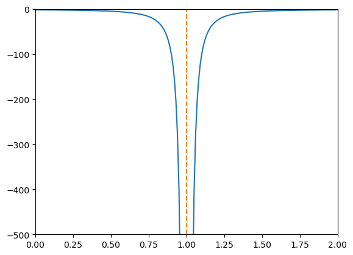

```python
import matplotlib.pyplot as plt
import numpy as np

x = np.linspace (1.01,2,100)
x1 = np.linspace (0,0.99,100)
plt.plot(x, -(1/(x-1)**2+1))
plt.plot(x1, -(1/(x1-1)**2+1),color='tab:blue')
plt.axvline(x = 1, color = 'tab:orange', linestyle = '--')
plt.axvline(x = 0, color = 'k')
plt.axhline(y = 0, color = 'k')
plt.ylim(-500,0)
plt.xlim(0,2)
```

Similar definitions can be given for the one-sided infinite limits.

\begin{equation} \lim_{x\to a^-} f(x) = \infty ~~~~~~ \lim_{x\to a^+} f(x) = \infty \end{equation}\begin{equation} \lim_{x\to a^-} f(x) = -\infty ~~~~~~ \lim_{x\to a^+} f(x) = -\infty \end{equation}

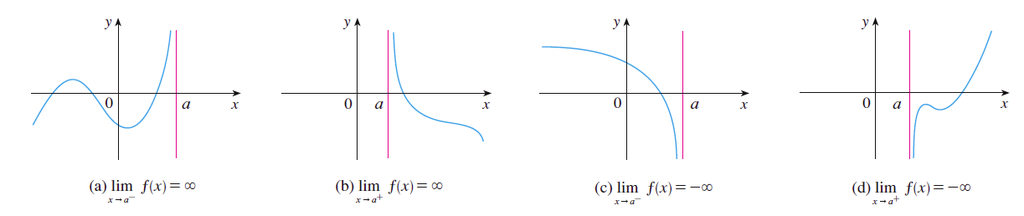

## Definition

The line $x=a$ is called a **vertical asymptote** of the curve $y=f(x)$ if at least one of the following statements is true:

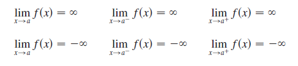

**Examples**

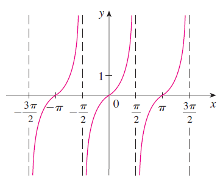

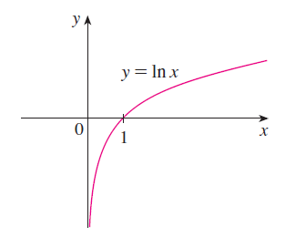

- $\lim_{x\to 0^+} \ln x = -\infty $
- $\lim_{x\to \pi/2^-} \tan x= \infty $
- $\lim_{x\to \pi/2^+} \tan x= -\infty $

## Definition

Let $f$ be defined on some interval $(a,\infty)$. Then

\begin{equation} \lim_{x\to \infty} f(x) = L \end{equation}

means that the values of $f(x)$ can be made arbitrarily close to $L$ by taking $x$ sufficiently large positive.

That is,

\begin{equation} \lim_{x\to \infty} f(x) = L \Leftrightarrow \forall ~~~ \epsilon > 0 ~~~ \exists ~~ M>0 ~\big / x>M \Rightarrow |f(x)-L|<\epsilon \end{equation}

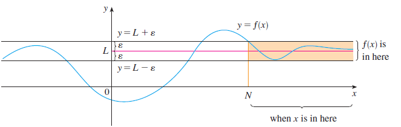

```
(-1.0, 2.0)
```

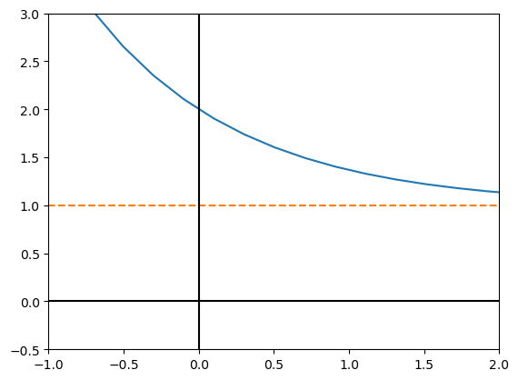

```python
import matplotlib.pyplot as plt
import numpy as np

x = np.linspace (-10,10,100)
x1 = np.linspace (0,0.99,100)
plt.plot(x, np.exp(-x)+1)

plt.axhline(y = 1, color = 'tab:orange', linestyle = '--')
plt.axvline(x = 0, color = 'k')
plt.axhline(y = 0, color = 'k')
plt.ylim(-0.5,3)
plt.xlim(-1,2)
```

## Definition

Let $f$ be defined on some interval $(-\infty,a)$. Then

\begin{equation} \lim_{x\to -\infty} f(x) = L \end{equation}

means that the values of $f(x)$ can be made arbitrarily close to $L$ by taking $x$ sufficiently large negative.

That is,

\begin{equation} \lim_{x\to -\infty} f(x) = L \Leftrightarrow \forall ~~~ \epsilon > 0 ~~~ \exists ~~ M<0 ~\big / x<M \Rightarrow |f(x)-L|<\epsilon \end{equation}

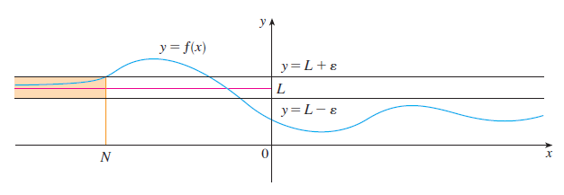

## Definition

The line $y=L$ is called a **horizontal asymptote** of the curve $y=f(x)$ if either

\begin{equation} \lim_{x\to \infty} f(x) = L ~~~~ or ~~~~ \lim_{x\to -\infty} f(x) = L \end{equation}

```
(-10.0, 10.0)
```

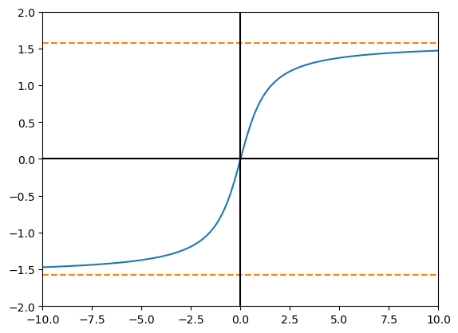

```python
import matplotlib.pyplot as plt
import numpy as np

x = np.linspace (-10,10,100)

plt.plot(x, np.arctan(x))

plt.axhline(y = np.pi/2, color='tab:orange', linestyle = '--')
plt.axhline(y = -np.pi/2, color='tab:orange', linestyle = '--')
plt.axvline(x = 0, color = 'k')
plt.axhline(y = 0, color = 'k')
plt.ylim(-2,2)
plt.xlim(-10,10)
```

\begin{equation} \lim_{x\to -\infty} e^x=0 \end{equation}

```
(-5.0, 2.0)
```

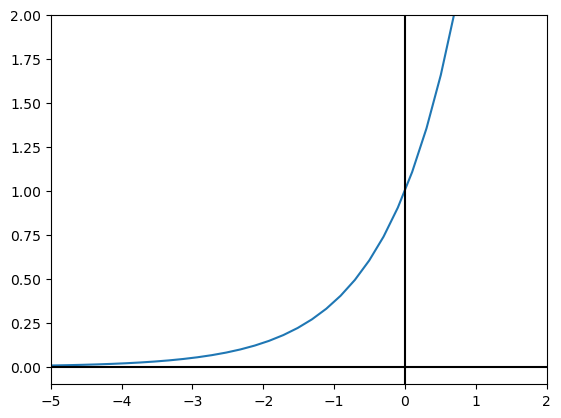

```python
plt.plot(x, np.exp(x))
plt.axvline(x = 0, color = 'k')
plt.axhline(y = 0, color = 'k')
plt.ylim(-0.1,2)
plt.xlim(-5,2)
```

**Exercise 1**

Find the value of the limit if it does exist.

a. $\lim_{x\to 3} \frac{2x}{x-3} $

b. $\lim_{x\to 3} \frac{2x}{(x-3)^2} $

c. $\lim_{x\to 0} f(x) $, $f(x)=\left\lbrace \begin{array}{ll} 0, ~~x<0 \\ 1,~~x\ge0 \end{array} \right.$

d.$\lim_{x\to 0} f(x) $, $f(x)=|x|$

e. $\lim_{x\to 0} f(x) $, $f(x)=\left\lbrace \begin{array}{ll} x-x^2, ~~x<0 \\ 1,~~x = 0 \\ \sin x,~~ x >0 \end{array} \right.$

Plot of (a):

```
(-150.0, 150.0)
```

[figure not shown]

```python
import numpy as np
import matplotlib.pyplot as plt

x = np.linspace(0,6,100)

plt.plot(x1,2*x1/(x1-3))
plt.axvline(x = 3, color = 'k', linestyle = '--')

plt.xlim(1,5)
plt.ylim(-150,150)
```

Plot of (b):

```
(-100.0, 700.0)
```

[figure not shown]

```python
import numpy as np
import matplotlib.pyplot as plt

x = np.linspace(0,6,100)

plt.plot(x1,2*x1/(x1-3)**2)
plt.axvline(x = 3, color = 'k', linestyle = '--')

plt.xlim(1,5)
plt.ylim(-100,700)
```

## Limits Laws

Suppose that $c$ is a constant and the limits below exist

\begin{equation} \lim_{x\to a} f(x) ~~~ and ~~~ \lim_{x\to a} g(x) \end{equation}

Then,

1. $\lim_{x\to a} [f(x)+g(x)]=\lim_{x\to a} f(x)+\lim_{x\to a} g(x) $
1. $\lim_{x\to a} [f(x)-g(x)]=\lim_{x\to a} f(x)-\lim_{x\to a} g(x) $
1. $\lim_{x\to a} [cf(x)]=c\lim_{x\to a} f(x) $
1. $\lim_{x\to a} [f(x)\cdot g(x)]=\lim_{x\to a} f(x)\cdot\lim_{x\to a} g(x) $
1. $\lim_{x\to a} [f(x)/ g(x)]=\lim_{x\to a} f(x)/\lim_{x\to a} g(x) $ if $\lim_{x\to a} g(x) \ne 0$

**Exercise 2**

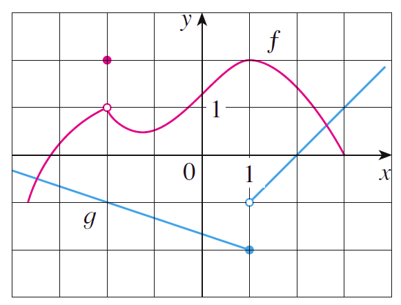

Use the Limit Laws and the graphs of $f$ and $g$ in the figure to evaluate the following limits, if they exist.

a. $\lim_{x\to -2} [f(x)+5g(x)]$

b. $\lim_{x\to 1} [f(x)\cdot g(x)]$

c. $\lim_{x\to 2} [f(x)/g(x)]$

More laws...

1. $\lim_{x\to a} [f(x)^n]=\big[\lim_{x\to a} f(x)\big]^n $, $n=1,2,3,...$
1. $\lim_{x\to a} c=c $
1. $\lim_{x\to a} x=a $
1. $\lim_{x\to a} [x^n]=a^n $
1. $\lim_{x\to a} \sqrt[n]{x}=\sqrt[n]{a}$, if $n$ is even $a\ge0$
1. $\lim_{x\to a} \sqrt[n]{f(x)}=\sqrt[n]{\lim_{x\to a} f(x)}$, if $n$ is even $\lim_{x\to a} f(x)\ge0$
1. $\lim_{x\to a} \ln \big( f(x) \big)=\ln\big(\lim_{x\to a} f(x)\big)$, $\lim_{x\to a} f(x)>0$
1. $\lim_{x\to a} \sin \big( f(x) \big)=\sin\big(\lim_{x\to a} f(x)\big)$

## Direct substitution property

If $f$ is a polynomial or a rational function and $a$ is in the domain of $f$, then

\begin{equation} \lim_{x\to a} f(x) = f(a) \end{equation}

**Example**

Find

\begin{equation} \lim_{x\to\infty} \frac{1}{x} ~~ and ~~ \lim_{x\to-\infty} \frac{1}{x} \end{equation}

When $x$ is large, $1/ x$ is small. For instance,

\begin{equation} \frac{1}{100} = 0.01 ~~~ \frac{1}{10,000} = 0.0001 ~~~ \frac{1}{1,000,000} = 0.000001 \end{equation}

In fact, by taking $x$ large enough, we can make $f(x)$ as close to $0$ as we please.

\begin{equation} \frac{1}{x} < \epsilon \Rightarrow x > \frac{1}{\epsilon}=M \end{equation}

Therefore, we can make $1/x$ arbitrarily close to $0$ by taking $x$ suficiently large. We can conclude that,

\begin{equation} \lim_{x\to\infty} \frac{1}{x}=0 \end{equation}

## Theorem

If $r>0$ is a rational number, then

\begin{equation} \lim_{x\to\infty} \frac{1}{x^r}=0 \end{equation}

If $r>0$ is a rational number such that $x^r$ is defined for all $x$, then

\begin{equation} \lim_{x\to-\infty} \frac{1}{x^r}=0 \end{equation}

## Theorem

If $f(x)\le g(x)$ when $x$ is near $a$ (except possibly at $a$) and the limits of $f$ and $g$ both exist as approaches $a$, then

\begin{equation} \lim_{x\to a} f(x)\le\lim_{x\to a} g(x) \end{equation}

## THE SQUEEZE THEOREM

If $f(x)\le g(x)\le h(x)$ when $x$ is near $a$ (except possibly at $a$) and

\begin{equation} \lim_{x\to a} f(x)=\lim_{x\to a} h(x)=L \end{equation}

then

\begin{equation} \lim_{x\to a} g(x)=L \end{equation}

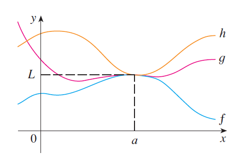

## Indeterminations

\begin{equation} \frac{0}{0},~~~ \frac{\infty}{\infty},~~~ \infty-\infty,~~~ 1^\infty,~~~ \infty^0,~~ 0^0 \end{equation}

1. $\frac{0}{0}\rightarrow$ simplify
1. $\frac{\infty}{\infty}\rightarrow$ comparison, $x^x>a^x>x^a>\log_a x$
1. $\infty-\infty \rightarrow $ convert into a $\frac{0}{0}$ or $\frac{\infty}{\infty}$

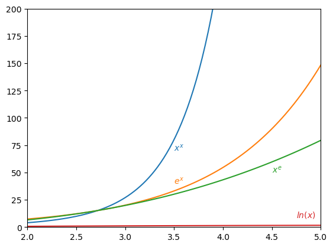

```python
import matplotlib.pyplot as plt
import numpy as np

x=np.linspace(2,5,100)

plt.plot(x,x**x)
plt.plot(x,np.e**x)
plt.plot(x,x**np.e)
plt.plot(x,np.log(x))

plt.ylim(0,200)
plt.xlim(2,5)
plt.annotate('$x^x$',xy=(3.5,70), color='tab:blue')
plt.annotate('$e^x$',xy=(3.5,40), color='tab:orange')
plt.annotate('$x^e$',xy=(4.5,50), color='tab:green')
plt.annotate('$ln(x)$',xy=(4.75,9), color='tab:red')
```

**Exercise 3**

Find

\begin{equation} \lim_{x\to 1} \frac{x^2-1}{x-1} \end{equation}

**Exercise 4**

Evaluate the following limits. $\frac{0}{0}\rightarrow$ simplify

a. $\lim_{x\to 2} \frac{x^2+x-6}{x-2}$

b. $\lim_{x\to -4} \frac{x^2+5x+4}{x^2+3x-4}$

c. $\lim_{x\to 0} \frac{\sqrt{x^2+9}-3}{x^2}$

**Exercise 5**

Evaluate the following limits. $\frac{\infty}{\infty}\rightarrow$ Comparison

a. $\lim_{x\to \infty} \frac{x^3}{3^x}$

b. $\lim_{x\to \infty} \frac{2^x+\ln x}{x^x}$

c. $\lim_{x\to \infty} \frac{\sqrt{x^2+1}-3}{x}$

**Exercise 6**

Evaluate the following limits. $\infty- \infty\rightarrow$ Convert

a. $\lim_{x\to \infty} \sqrt{x+2}-\sqrt{x-2}$

b. $\lim_{x\to 2} \ln\big(x^2-4\big)-\ln\big(x-2\big)$

c. $\lim_{x\to 2}\big[ \log_{10}\big(\sqrt x+1\big)-2\log_{10} \sqrt{x}+\log_{10}\big(\sqrt{x}-1\big)\big]$

## Review

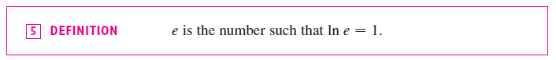

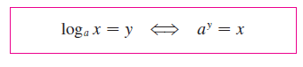

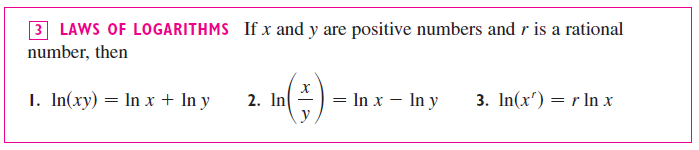

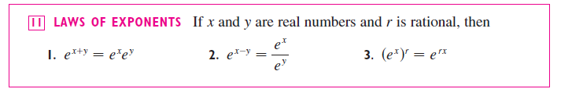

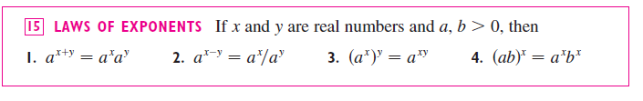

## Special Limit

\begin{equation} \lim_{x\to 0} \frac{\sin x}{x}=1 \end{equation}

**Proof:**

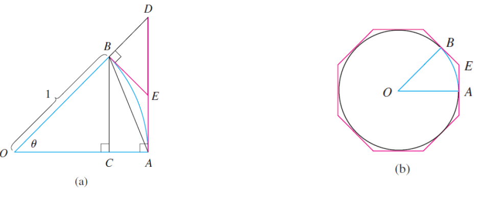

From (b)

$arclenght=radius\cdot\theta(rad) $ $\Rightarrow ~ arc ~AB=1\cdot \theta$

From (a)

$BC<AB<arc~AB$ and $BC=\sin\theta$

\begin{equation}\Rightarrow sin\theta<\theta\end{equation}

\begin{equation} or~~~ \frac{sin\theta}{\theta}<1 \end{equation}

On the other hand,

\begin{equation} \tan \theta = \frac{AD}{AO}=\frac{AD}{1}>\theta \end{equation}

\begin{equation} \Rightarrow \frac{\sin \theta}{\cos \theta} >\theta \Rightarrow \cos \theta < \frac{\sin \theta}{\theta} \end{equation}

then ...

\begin{equation} \cos \theta < \frac{\sin \theta}{\theta} < 1 \end{equation}

taking limits $\theta \rightarrow 0$

\begin{equation} \lim_{x\to 0} \cos \theta < \lim_{x\to 0} \frac{\sin \theta}{\theta} < \lim_{x\to 0} 1 \end{equation}\begin{equation} \Rightarrow 1 < \lim_{x\to 0} \frac{\sin \theta}{\theta} < 1 \end{equation}\begin{equation} \Rightarrow \lim_{x\to 0} \frac{\sin \theta}{\theta} =1 \end{equation}

**Exercise 7**

a. $\lim_{x\to 0}\frac{sin(3x)}{x}$

b. $\lim_{x\to 0} \frac{sin(2x^2)}{- x}$

c. $\lim_{x\to 0} \frac{cos(x)-1}{x}$

d. $\lim_{x\to 0} \frac{cos(2x)-1}{x^ 2}$

## Some useful approximations

- if $f(x)\rightarrow 0\Rightarrow \sin\big(f(x)\big)\approx f(x)$ $\Rightarrow \sin \approx$ line close to the origin
- if $f(x)\rightarrow 0\Rightarrow \cos\big(f(x)\big)\approx 1- \big[f(x)\big]^ 2\big/2$ $\Rightarrow \cos \approx$ parabola close to the origin

## Indeterminations $1^\infty$, $0^0$, $\infty^0$

This limits are solved applying logarithms to them in both sides. This limits are solved applying and approximating $\ln\big(f(x)\big)\approx f(x)-1$

1. \begin{equation}\lim_{x\to \infty} \big(\frac{x-4}{x-1}\big)^{x-3}\end{equation}
1. \begin{equation}\lim_{x\to \infty} \big(1+\frac{2}{x}\big)^{x}\end{equation}
1. \begin{equation}\lim_{x\to 0^+} \big(1+\sin(4x)\big)^{\cot x}\end{equation}

# Limits in $\Re^3$

### Definition

Let $f$ be a function of two variables whose domain $D$ includes points arbitrarily close to (a,b). Then we say that the **limit of** $f(x,y)$ as $(x,y)$ approaches $(a,b)$ is $L$ and we write

\begin{equation} \lim_{(x,y)\to (a,b)} f(x,y)=L \end{equation}

if for every number $\epsilon>0$ there is a corresponding number $\delta>0$ such that if $(x,y)\in D$ and $\sqrt{(x-a)^2+(y-b)^ 2}<\delta$ then $|f(x,y)-L|<\epsilon$.

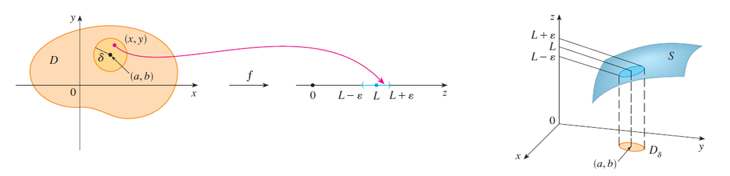

- In $\Re^3$ there are $\infty$ many directions to approach to the limit, not only left and right.
- If the limit depend on the direction, this is, it depends on $\theta$, it will not exist.
- The limit exists if

\begin{equation} \lim_{(x,y)\to (a,b)} f(x,y)=\lim_{\rho\to 0~~~ \forall ~ \theta} f(x_0+\rho\cos \theta,y_0+\rho\sin \theta) \end{equation}

**Exercise 8**

1. \begin{equation}\lim_{(x,y)\to (1,2)} (5x^ 3-x^2y^2)\end{equation}
1. \begin{equation}\lim_{(x,y)\to (1,2)} \frac{x+1}{y-2}\end{equation}
1. \begin{equation}\lim_{(x,y)\to (0,1)} \big(\frac{x}{y}\cos \frac{x}{y}\big)\end{equation}

**Exercise 9** Indeterminations $\infty/\infty$

1. \begin{equation}\lim_{(x,y)\to (\infty,\infty)} \big(2x/y^2\big)\end{equation}
1. \begin{equation}\lim_{(x,y)\to (\infty,\infty)} \big(2^x/y^5\big)\end{equation}
1. \begin{equation} \lim_{(x,y)\to (\infty,\infty)} \frac{x^3-2xy}{ xy^2+x^2y}\end{equation}
1. \begin{equation} \lim_{(x,y)\to (\infty,\infty)} \frac{2^x+x^2}{ 3^y+xy} \end{equation}
1. \begin{equation} \lim_{(x,y)\to (\infty,\infty)} \frac{2^{xy}}{ 3^x} \end{equation}
1. \begin{equation} \lim_{(x,y)\to (\infty,\infty)} \frac{\sin x}{ y} \end{equation}

**Exercise 10** Indeterminations $0/0$

1. \begin{equation}\lim_{(x,y)\to (9,9)} \frac{x-y}{\sqrt{x}-\sqrt{y}}\end{equation}
1. \begin{equation}\lim_{(x,y)\to (0,0)} \frac{xy}{x^2+y^2}\end{equation}
1. \begin{equation}\lim_{(x,y)\to (0,0)} \frac{\cos x -1}{y^2}\end{equation}
1. \begin{equation}\lim_{(x,y)\to (2,0)} \frac{\sin y }{2x-4}\end{equation}